# Covid 19 Trends

Bart Baranowski

10/08/2020

# Understanding the data

## Loading the dataset from the `covid19.csv` CSV file and quick exploration

```r
library(readr)
# Loading the dataset
covid_df <- read_csv("covid19.csv")
# Displaying the dimension of the data
dim(covid_df)
```

```
## [1] 10903    14
```

```r
# Storing the column names in a variable
vector_cols <- colnames(covid_df)
# Displaying the variable vector_cols
vector_cols
```

```
##  [1] "Date"                    "Continent_Name"
##  [3] "Two_Letter_Country_Code" "Country_Region"
##  [5] "Province_State"          "positive"
##  [7] "hospitalized"            "recovered"
##  [9] "death"                   "total_tested"
## [11] "active"                  "hospitalizedCurr"
## [13] "daily_tested"            "daily_positive"
```

```r
# Showing the first few rows of the dataset
head(covid_df)
```

```
## # A tibble: 6 x 14
##   Date       Continent_Name Two_Letter_Coun… Country_Region Province_State
##   <date>     <chr>          <chr>            <chr>          <chr>
## 1 2020-01-20 Asia           KR               South Korea    All States
## 2 2020-01-22 North America  US               United States  All States
## 3 2020-01-22 North America  US               United States  Washington
## 4 2020-01-23 North America  US               United States  All States
## 5 2020-01-23 North America  US               United States  Washington
## 6 2020-01-24 Asia           KR               South Korea    All States
## # … with 9 more variables: positive <dbl>, hospitalized <dbl>, recovered <dbl>,
## #   death <dbl>, total_tested <dbl>, active <dbl>, hospitalizedCurr <dbl>,
## #   daily_tested <dbl>, daily_positive <dbl>
```

```r
# Showing a global view of the dataset
library(tibble)
glimpse(covid_df)
```

```
## Rows: 10,903
## Columns: 14
## $ Date                    <date> 2020-01-20, 2020-01-22, 2020-01-22, 2020-01-…
## $ Continent_Name          <chr> "Asia", "North America", "North America", "No…
## $ Two_Letter_Country_Code <chr> "KR", "US", "US", "US", "US", "KR", "US", "US…
## $ Country_Region          <chr> "South Korea", "United States", "United State…
## $ Province_State          <chr> "All States", "All States", "Washington", "Al…
## $ positive                <dbl> 1, 1, 1, 1, 1, 2, 1, 1, 4, 0, 3, 0, 0, 0, 0, …
## $ hospitalized            <dbl> 0, 0, 0, 0, 0, 0, 0, 0, 0, 0, 0, 0, 0, 0, 0, …
## $ recovered               <dbl> 0, 0, 0, 0, 0, 0, 0, 0, 0, 0, 0, 0, 0, 0, 0, …
## $ death                   <dbl> 0, 0, 0, 0, 0, 0, 0, 0, 0, 0, 0, 0, 0, 0, 0, …
## $ total_tested            <dbl> 4, 1, 1, 1, 1, 27, 1, 1, 0, 0, 0, 0, 0, 0, 0,…
## $ active                  <dbl> 0, 0, 0, 0, 0, 0, 0, 0, 0, 0, 0, 0, 0, 0, 0, …
## $ hospitalizedCurr        <dbl> 0, 0, 0, 0, 0, 0, 0, 0, 0, 0, 0, 0, 0, 0, 0, …
## $ daily_tested            <dbl> 0, 0, 0, 0, 0, 5, 0, 0, 0, 0, 0, 0, 0, 0, 0, …
## $ daily_positive          <dbl> 0, 0, 0, 0, 0, 0, 0, 0, 0, 0, 0, 0, 0, 0, 0, …
```

The dataset contains `14` columns and `10,903` rows. This database provides information about the numbers (per day and cumulatively) of COVID-19 positive cases, deaths, tests performed and hospitalizations for each country through the column’s names store in the variable `vector_cols`.

# Isolating the data I need

## Selecting only the rows related to `"All States"` and removing the `Province_State`.

```r
library(dplyr)
# Filter the "All States" Province states and remove the `Province_State` column
covid_df_all_states <- covid_df %>%
  filter(Province_State == "All States") %>%
  select(-Province_State)
```

## Creating a dataset for the cumulative columns and another for the daily columns from `covid_df_all_states` dataframe

Let’s recall the description of the dataset’s columns.

1. `Date`: Date
2. `Continent_Name`: Continent names
3. `Two_Letter_Country_Code`: Country codes
4. `Country_Region`: Country names
5. `Province_State`: States/province names; value is `All States` when state/provincial level data is not available
6. `positive`: Cumulative number of positive cases reported.
7. `active`: Number of actively cases on that **day**.
8. `hospitalized`: Cumulative number of hospitalized cases reported.
9. `hospitalizedCurr`: Number of actively hospitalized cases on that **day**.
10. `recovered`: Cumulative number of recovered cases reported.
11. `death`: Cumulative number of deaths reported.
12. `total_tested`: Cumulative number of tests conducted.
13. `daily_tested`: Number of tests conducted on the **day**; if daily data is unavailable, daily tested is averaged across number of days in between.
14. `daily_positive`: Number of positive cases reported on the **day**; if daily data is unavailable, daily positive is averaged across number of days in.

```r
# Selecting the columns with cumulative numbers
covid_df_all_states_cumulative <- covid_df_all_states %>%
  select(Date, Continent_Name, Two_Letter_Country_Code, positive, hospitalized, recovered, death, total_tested)
# Selecting the columns with cumulative numbers
covid_df_all_states_daily <- covid_df_all_states %>%
  select(Date, Country_Region, active, hospitalizedCurr, daily_tested, daily_positive)
##print(xtable::xtable(head(covid_df_all_states_daily)), type = "html")
```

1. We can remove `Province_State` without loosing information because after the filtering step this column only contains the value `"All States"`.

# Identifying the highest fatality rate countries

## Summarizing the data based on the `Continent_Name` and `Two_Letter_Country_Code` columns.

```r
covid_df_all_states_cumulative_max <- covid_df_all_states_cumulative %>%
  group_by(Continent_Name, Two_Letter_Country_Code) %>%
  summarise(max = max(death)) %>%
  filter(max > 0)
covid_df_all_states_cumulative_max
```

```
## # A tibble: 24 x 3
## # Groups:   Continent_Name [4]
##    Continent_Name Two_Letter_Country_Code   max
##    <chr>          <chr>                   <dbl>
##  1 Asia           AM                        139
##  2 Asia           BD                        672
##  3 Asia           IL                        279
##  4 Asia           KR                        271
##  5 Asia           RU                       4693
##  6 Asia           SG                         23
##  7 Asia           TR                       4540
##  8 Europe         BE                       8903
##  9 Europe         EE                         68
## 10 Europe         GB                      33186
## # … with 14 more rows
```

## Displaying the maximum number of death by country, colored by continent

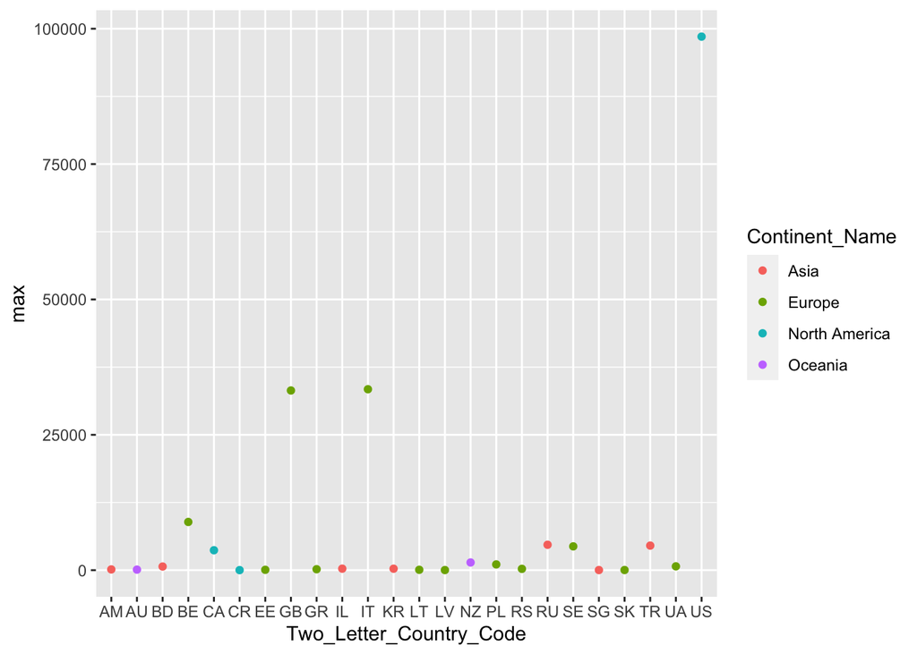

```r
library(ggplot2)
qplot(x = Two_Letter_Country_Code,
      y = max,
      col = Continent_Name,
      data = covid_df_all_states_cumulative_max)
```

## Answering the question: Which countries have had the highest fatality (mortality) rates?

```r
death_top_3 <- c("US", "IT", "GB")
```

# Extracting the top 10 countries in the number of tested cases

## Summarizing the data based on the `Country_Region` column.

```r
covid_df_all_states_daily_sum <- covid_df_all_states_daily %>%
  group_by(Country_Region) %>%
  summarise(tested = sum(daily_tested),
            positive = sum(daily_positive),
            active = sum(active),
            hospitalized = sum(hospitalizedCurr)) %>%
  arrange(desc(tested)) #this is equivalent to `arrange(-tested)`
covid_df_all_states_daily_sum
```

```
## # A tibble: 108 x 5
##    Country_Region   tested positive  active hospitalized
##    <chr>             <dbl>    <dbl>   <dbl>        <dbl>
##  1 United States  17282363  1877179       0            0
##  2 Russia         10542266   406368 6924890            0
##  3 Italy           4091291   251710 6202214      1699003
##  4 India           3692851    60959       0            0
##  5 Turkey          2031192   163941 2980960            0
##  6 Canada          1654779    90873   56454            0
##  7 United Kingdom  1473672   166909       0            0
##  8 Australia       1252900     7200  134586         6655
##  9 Peru             976790    59497       0            0
## 10 Poland           928256    23987  538203            0
## # … with 98 more rows
```

```r
#Date, Country_Region, active, hospitalizedCurr, daily_tested, daily_positive
```

## Taking the top 10

```r
covid_top_10 <- head(covid_df_all_states_daily_sum, 10)
#print(xtable::xtable(covid_top_10), type = "html")
```

# Identifying the highest positive against tested cases

## Getting vectors

```r
countries <- covid_top_10$Country_Region
tested_cases <- covid_top_10$tested
positive_cases <- covid_top_10$positive
active_cases <- covid_top_10$active
hospitalized_cases <- covid_top_10$hospitalized
```

## Naming vectors

```r
names(positive_cases) <- countries
names(tested_cases) <- countries
names(active_cases) <- countries
names(hospitalized_cases) <- countries
```

## Identifying

```r
positive_cases
```

```
##  United States         Russia          Italy          India         Turkey
##        1877179         406368         251710          60959         163941
##         Canada United Kingdom      Australia           Peru         Poland
##          90873         166909           7200          59497          23987
```

```r
sum(positive_cases)
```

```
## [1] 3108623
```

```r
mean(positive_cases)
```

```
## [1] 310862.3
```

```r
positive_cases/sum(positive_cases)
```

```
##  United States         Russia          Italy          India         Turkey
##    0.603861903    0.130722831    0.080971543    0.019609647    0.052737498
##         Canada United Kingdom      Australia           Peru         Poland
##    0.029232557    0.053692262    0.002316138    0.019139342    0.007716278
```

```r
positive_cases/tested_cases
```

```
##  United States         Russia          Italy          India         Turkey
##    0.108618191    0.038546552    0.061523368    0.016507300    0.080711720
##         Canada United Kingdom      Australia           Peru         Poland
##    0.054915490    0.113260617    0.005746668    0.060910738    0.025840932
```

## Conclusion

```r
positive_tested_top_3 <- c("United Kingdom" = 0.11, "United States" = 0.10, "Turkey" = 0.08)
```